# Breast Cancer Wisconsin (Diagnostic)

```r
modelrandomForest$mtry
```

```
[1] 5
```

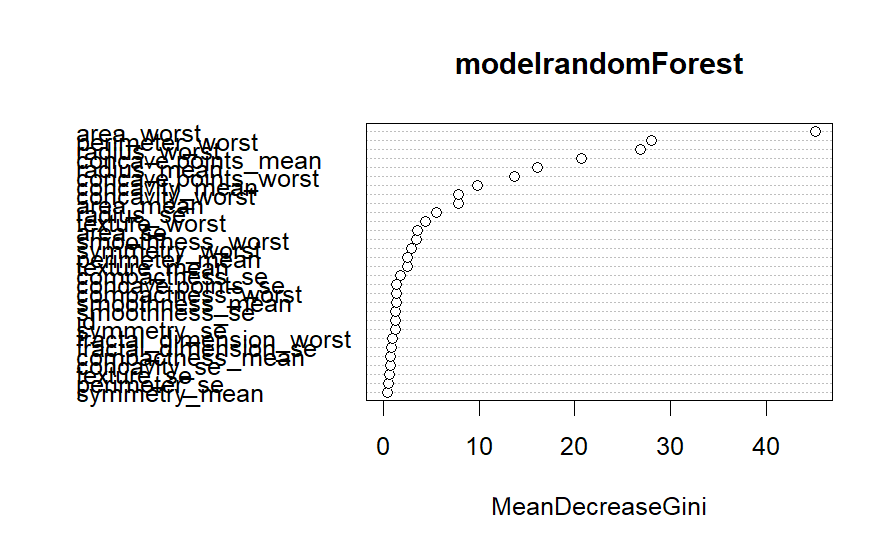

```r
varImpPlot(modelrandomForest)
```

ntree: Number of trees in the forest. mtry: Number of variables randomly chosen at each split. err.rate: Shows model error over the trees. varImpPlot(): Displays which features are most important in classification.

Random Forest generally gives more stable and accurate predictions than a single decision tree because it averages multiple trees and reduces overfitting.

```r
predictionrandomf<-predict(modelrandomForest,testdata)
confusionMatrix(predictionrandomf,testdata$diagnosis)
```

```
Confusion Matrix and Statistics

          Reference
Prediction  B  M
         B 79  2
         M  0 33

               Accuracy : 0.9825
                 95% CI : (0.9381, 0.9979)
    No Information Rate : 0.693
    P-Value [Acc > NIR] : 9.152e-16

                  Kappa : 0.9581

 Mcnemar's Test P-Value : 0.4795

            Sensitivity : 1.0000
            Specificity : 0.9429
         Pos Pred Value : 0.9753
         Neg Pred Value : 1.0000
             Prevalence : 0.6930
         Detection Rate : 0.6930
   Detection Prevalence : 0.7105
      Balanced Accuracy : 0.9714

       'Positive' Class : B
```

```r
confusionMatrix(predictionrandomf,testdata$diagnosis,positive = "M")
```

```
Confusion Matrix and Statistics

          Reference
Prediction  B  M
         B 79  2
         M  0 33

               Accuracy : 0.9825
                 95% CI : (0.9381, 0.9979)
    No Information Rate : 0.693
    P-Value [Acc > NIR] : 9.152e-16

                  Kappa : 0.9581

 Mcnemar's Test P-Value : 0.4795

            Sensitivity : 0.9429
            Specificity : 1.0000
         Pos Pred Value : 1.0000
         Neg Pred Value : 0.9753
             Prevalence : 0.3070
         Detection Rate : 0.2895
   Detection Prevalence : 0.2895
      Balanced Accuracy : 0.9714

       'Positive' Class : M
```

Here, I tune Random Forest hyperparameters using random and grid search. I also extract classification metrics for further analysis.

```r
modelLookup("rf")
```

|  | model | parameter | label | forReg | forClass | probModel |
| --- | --- | --- | --- | --- | --- | --- |
| 1 | rf | mtry | #Randomly Selected Predictors | TRUE | TRUE | TRUE |

```r
randomcontrol<-trainControl(method="repeatedcv",number=10,repeats = 3,search="random")
modelrftune<-train(diagnosis~.,data=traindata,method="rf",
                   tuneLength=7,trControl=randomcontrol)
randomcontrol2<-trainControl(method="cv",number=5,search="grid")
modelrfgrid<-train(diagnosis~.,data=traindata,method="rf",
                    tuneGrid=expand.grid(mtry=1:9),
                    trControl=randomcontrol2)
predictrandomtune<-predict(modelrftune$finalModel,testdata)
predictrandomgrid<-predict(modelrfgrid$finalModel,testdata)
confusionMatrix(predictrandomtune,testdata$diagnosis)
```

```
Confusion Matrix and Statistics

          Reference
Prediction  B  M
         B 79  2
         M  0 33

               Accuracy : 0.9825
                 95% CI : (0.9381, 0.9979)
    No Information Rate : 0.693
    P-Value [Acc > NIR] : 9.152e-16

                  Kappa : 0.9581

 Mcnemar's Test P-Value : 0.4795

            Sensitivity : 1.0000
            Specificity : 0.9429
         Pos Pred Value : 0.9753
         Neg Pred Value : 1.0000
             Prevalence : 0.6930
         Detection Rate : 0.6930
   Detection Prevalence : 0.7105
      Balanced Accuracy : 0.9714

       'Positive' Class : B
```

```r
confusionMatrix(predictrandomgrid,testdata$diagnosis)
```

```
Confusion Matrix and Statistics

          Reference
Prediction  B  M
         B 79  2
         M  0 33

               Accuracy : 0.9825
                 95% CI : (0.9381, 0.9979)
    No Information Rate : 0.693
    P-Value [Acc > NIR] : 9.152e-16

                  Kappa : 0.9581

 Mcnemar's Test P-Value : 0.4795

            Sensitivity : 1.0000
            Specificity : 0.9429
         Pos Pred Value : 0.9753
         Neg Pred Value : 1.0000
             Prevalence : 0.6930
         Detection Rate : 0.6930
   Detection Prevalence : 0.7105
      Balanced Accuracy : 0.9714

       'Positive' Class : B
```

```r
cm<-confusionMatrix(predictionrandomf,testdata$diagnosis)
cm$byClass[c("Precision","Recall","F1")]
```

```
Precision    Recall        F1
0.9753086 1.0000000 0.9875000
```

```r
cm_dt <- confusionMatrix(predictmodelTunemin, data = testdata$diagnosis, positive = "B")
cm_rf <- confusionMatrix(predictrandomgrid, testdata$diagnosis, positive = "B")

results <- data.frame(
  Model = c("Tuned Decision Tree (rpart)", "Tuned Random Forest (rf)"),
  Accuracy = c(cm_dt$overall['Accuracy'], cm_rf$overall['Accuracy']),
  Recall = c(cm_dt$byClass['Recall'], cm_rf$byClass['Recall']),
  Precision = c(cm_dt$byClass['Precision'], cm_rf$byClass['Precision'])
)

print(results)
```

| Model | Accuracy | Recall | Precision |
| --- | --- | --- | --- |
| Tuned Decision Tree (rpart) | 0.9385965 | 0.9390244 | 0.9746835 |
| Tuned Random Forest (rf) | 0.9824561 | 1.0000000 | 0.9753086 |

Both Decision Tree and Random Forest successfully classified the tumors. However, Random Forest achieved higher accuracy and lower error due to its ensemble approach. This shows that combining multiple weak learners creates a more powerful and reliable model — especially in medical data where precision is crucial.